# Self-Driving Car Engineer Nanodegree

## Project: Build a Traffic Sign Recognition Classifier

In this notebook, a template is provided for you to implement your functionality in stages which is required to successfully complete this project. If additional code is required that cannot be included in the notebook, be sure that the Python code is successfully imported and included in your submission, if necessary. Sections that begin with **'Implementation'** in the header indicate where you should begin your implementation for your project. Note that some sections of implementation are optional, and will be marked with **'Optional'** in the header.

In addition to implementing code, there will be questions that you must answer which relate to the project and your implementation. Each section where you will answer a question is preceded by a **'Question'** header. Carefully read each question and provide thorough answers in the following text boxes that begin with **'Answer:'**. Your project submission will be evaluated based on your answers to each of the questions and the implementation you provide.

> **Note:** Code and Markdown cells can be executed using the **Shift + Enter** keyboard shortcut. In addition, Markdown cells can be edited by typically double-clicking the cell to enter edit mode.

## Step 0: Load The Data

```python
# Load pickled data
import pickle

# TODO: Fill this in based on where you saved the training and testing data
## Please change this to folder where you place the notebook

training_file = './Data/train.p'
testing_file = './Data/test.p'

try:
    with open(training_file, mode='rb') as f:
        train = pickle.load(f)
    with open(testing_file, mode='rb') as f:
        test = pickle.load(f)

    X_train, y_train = train['features'], train['labels']
    X_test, y_test = test['features'], test['labels']

    print('Training and Test datasets loaded.')

except Exception as e:
    print('Loading datasets failure')
```

```
Training and Test datasets loaded.
```

## Step 1: Dataset Summary & Exploration

The pickled data is a dictionary with 4 key/value pairs:

- `'features'` is a 4D array containing raw pixel data of the traffic sign images, (num examples, width, height, channels).
- `'labels'` is a 1D array containing the label/class id of the traffic sign. The file `signnames.csv` contains id -> name mappings for each id.
- `'sizes'` is a list containing tuples, (width, height) representing the the original width and height the image.
- `'coords'` is a list containing tuples, (x1, y1, x2, y2) representing coordinates of a bounding box around the sign in the image. **THESE COORDINATES ASSUME THE ORIGINAL IMAGE. THE PICKLED DATA CONTAINS RESIZED VERSIONS (32 by 32) OF THESE IMAGES**

Complete the basic data summary below.

```python
### Replace each question mark with the appropriate value.

# TODO: Number of training examples
n_train = len(X_train)

# TODO: Number of testing examples.
n_test = len(X_test)

# TODO: What's the shape of an traffic sign image?
image_shape = X_train[0].shape

# TODO: How many unique classes/labels there are in the dataset.
n_classes = len(set(y_train))

print("Number of training examples =", n_train)
print("Number of testing examples =", n_test)
print("Image data shape =", image_shape)
print("Number of classes =", n_classes)
```

```
Number of training examples = 39209
Number of testing examples = 12630
Image data shape = (32, 32, 3)
Number of classes = 43
```

Visualize the German Traffic Signs Dataset using the pickled file(s). This is open ended, suggestions include: plotting traffic sign images, plotting the count of each sign, etc.

The [Matplotlib](http://matplotlib.org/) [examples](http://matplotlib.org/examples/index.html) and [gallery](http://matplotlib.org/gallery.html) pages are a great resource for doing visualizations in Python.

**NOTE:** It's recommended you start with something simple first. If you wish to do more, come back to it after you've completed the rest of the sections.

```python
import pandas as pd
signNames = pd.read_csv('signnames.csv', sep=',')

def SignDescription(SignIdx):
    signName = signNames[signNames['ClassId']==SignIdx]['SignName'][SignIdx]
    #print (signName)
    return signName
```

```
 ******* Sample images *******
```

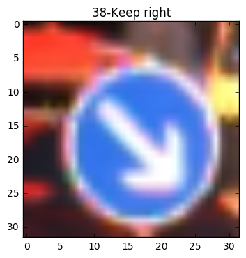

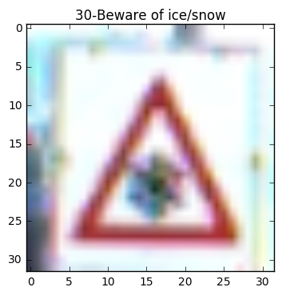

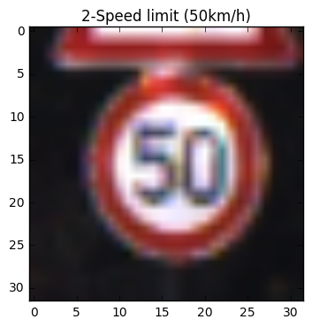

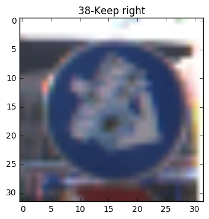

```python
### Data exploration visualization goes here.
### Feel free to use as many code cells as needed.
import random
import numpy as np
import matplotlib.pyplot as plt
%matplotlib inline

# Visualizations will be shown in the notebook.

# Plot four sample images
print(' ******* Sample images ******* ')
for i in range(4):
    index = random.randint(0, n_train)
    plt.imshow(train['features'][index])
    SignIdx = train['labels'][index]
    #print(str(SignIdx) + "-" + SignDescription(SignIdx))
    plt.title(str(SignIdx) + "-" + SignDescription(SignIdx))
    plt.show()
```

## Step 2: Design and Test a Model Architecture

Design and implement a deep learning model that learns to recognize traffic signs. Train and test your model on the [German Traffic Sign Dataset](http://benchmark.ini.rub.de/?section=gtsrb&subsection=dataset).

There are various aspects to consider when thinking about this problem:

- Neural network architecture
- Play around preprocessing techniques (normalization, rgb to grayscale, etc)
- Number of examples per label (some have more than others).
- Generate fake data.

Here is an example of a [published baseline model on this problem](http://yann.lecun.com/exdb/publis/pdf/sermanet-ijcnn-11.pdf). It's not required to be familiar with the approach used in the paper but, it's good practice to try to read papers like these.

**NOTE:** The LeNet-5 implementation shown in the classroom at the end of the CNN lesson is a solid starting point. You'll have to change the number of classes and possibly the preprocessing, but aside from that it's plug and play!

### Implementation

Use the code cell (or multiple code cells, if necessary) to implement the first step of your project. Once you have completed your implementation and are satisfied with the results, be sure to thoroughly answer the questions that follow.

```python
### Preprocess the data here.
# 1) MEAN SUBTRACTION
try:
    X_train_meanSub = X_train - np.mean(X_train, axis = 0)
    X_test_meanSub  = X_test - np.mean(X_test, axis = 0)
    print('Mean Subtraction performed succesfully')
except Exception as e:
    print('Mean Subtraction Failed')


# 2) NORMALIZATION
# I found 2 ways to normilze that I want to check how different these 2 techniques are.

def normalize(image_data):
    a = -0.5
    b = 0.5
    grayscale_min = 0
    grayscale_max = 255
    return a + ( ( (image_data - grayscale_min)*(b - a) )/( grayscale_max - grayscale_min ) )


X_train_norm1 = normalize(X_train_meanSub)
X_test_norm1 = normalize(X_test_meanSub)

X_train_norm2 = (X_train - X_train.mean()) / (np.max(X_train) - np.min(X_train))
X_test_norm2 = (X_test - X_test.mean()) / (np.max(X_test) - np.min(X_test))

#assert np.array_equal(X_train_norm1, X_train_norm2), 'Normalization techniques 1 and 2 are not producing equal images.'

def plot_norm_image(image_index):

    plt.figure(figsize=(10,6))

    plt.subplot(4,4,1)
    plt.imshow(train['features'][image_index]) # ORIGINAL

    plt.subplot(4,4,2)
    plt.imshow(X_train_meanSub[image_index]) # MEAN SUBTRACTION

    plt.subplot(4,4,3)
    plt.imshow(X_train_norm1[image_index]) # NORMALIZED METHOD 1

    plt.subplot(4,4,4)
    plt.imshow(X_train_norm2[image_index]) # NORMALIZED METHOD 2

# 3) PCA/Whitening is good for completeness, but these transformations are not used with Convolutional Networks in praactice.

### Feel free to use as many code cells as needed.
```

```
Mean Subtraction performed succesfully
```

[figure not shown]

```python
# This is to Compare a randomly selected image from the training set with is normalized versions to visualy inspect the diferences.
index = random.randint(0, n_train)
plot_norm_image(index)
```

### Question 1

*Describe how you preprocessed the data. Why did you choose that technique?*

**Answer:** Before I answer this question I’d like to elaborate the 2 different steps we use to pre-process the data before we feed it into the CNN and how these steps affect significantly the answer.

1. The first step is to manipulate the raw data simply because we want it to be within an acceptable range and format for the network. Transformation and normalization are two widely used preprocessing methods to achieve this objective. Transformation involves manipulating raw data inputs to create a single input to a net (many to one), while normalization is a manipulation performed on a single data input to distribute the data evenly and scale it into an acceptable range for the network (one to one). Knowledge of the domain is important in choosing preprocessing methods to highlight underlying features in the data, which can increase the network's ability to learn the association between inputs and outputs. There are many different types of manipulations depending on the field and type of data we are using. Some simple preprocessing methods include computing differences between or taking ratios of inputs. In financial forecasting transformations might involve the use of standard technical indicators. Also moving averages, for example, which are utilized to help smooth price data. Other methods for data normalization that I found out there are min-max normalization (which is what I used here), z-score normalization and normalization by decimal scaling. As can see below, I used 2 different Normalization techniques and I plotted a random image and its normalized 2 versions and decided to train the CNN with both to see if there is any significant change in accuracy and performance. After 2 runs on each I decided to stick with Normalization 2.
2. The second step after the data is ready for the net, is to shuffle the training data. But why? Well, the learning in a neural network follows a walk that minimizes the error which depends on the current example. Some walks will end at a local minimum while we are seeking a global one. Therefore if we always start the training at the same sample point we could end up stuck in that local minima over and over again and that’s why it is extremely important to shuffle the training data. I did want to mention an interesting line of research from Bengio et al. on something they call “curriculum learning”. Here’s a sentence from the opening paragraph: “By choosing which examples to present and in which order to present them to the learning system, one can guide training and remarkably increase the speed at which learning can occur.” On the same topic, I have read comments from people like Viresh Ranjan, PhD Student in Machine Learning where he states that theory and practice are totally different. Here’s what he said: “different random shuffling of the training set may lead to different parameters. In practice, doesn't make that much of a difference. Since the neural network objective functions are non-convex, using different ordering of training samples would lead to possibly different local minimas. However, in practice, we observe that using different ordering of training samples doesn't result in any drastic changes in performance.“ So going back to the question, after looking at the raw images we noticed that they are all 32x32x3. So we don't need to re-shape them and guarantee they have this size. Why 32x32x3...Well, we look for a minimal factor where images don’t lose any information and we convey to a 32x32x3. I WILL NOT SHUFFLE HERE UNTIL THE TRAINING DATA IS SPLIT INTO 2 DATASETS: FINAL TRAINING SET AND VALIDATION SET

```python
### Generate additional data (OPTIONAL!)
# Please read the answer for question 2 below in regard to generating additional data

### and split the data into training/validation/testing sets here.
 # Splitting below
### Feel free to use as many code cells as needed.
```

```python
#________________________________________
#         SPLITTING THE DATA
#________________________________________
# We will split the Original Training set into a final Training set and a Validation test.

from sklearn.utils import shuffle

def data_split(Input_images, Output_labels, train_percent=.8):
    m = len(Input_images)
    train_end = int(train_percent * m)

    #Shuffle before we slpit
    Input_images, Output_labels = shuffle(Input_images, Output_labels, random_state=42)

    X_train = Input_images[:train_end]
    y_train = Output_labels[:train_end]

    X_validation = Input_images[train_end:]
    y_validation = Output_labels[train_end:]

    return X_train, y_train, X_validation, y_validation
```

```python
# Here is where we actually split the data
#try:
train_percent = 0.8 # 80% will be final training data and 20% will used as a validation data
X_train_final, y_train_final, X_validation, y_validation = data_split(X_train_norm2, y_train, train_percent)

n_train_final = len(X_train_final)
n_validation = len(X_validation)

print("Number of Final training examples =", n_train_final)
print("% training examples =", n_train_final/n_train)
print("Number of Validation examples =", n_validation)

#except Exception as e:
#    print('Data Split failed')
```

```
Number of Final training examples = 31367
% training examples = 0.7999948991303018
Number of Validation examples = 7842
```

### Question 2

*Describe how you set up the training, validation and testing data for your model. **Optional**: If you generated additional data, how did you generate the data? Why did you generate the data? What are the differences in the new dataset (with generated data) from the original dataset?*

**Answer:** Just after a quick research I realized that deciding the percentages of the full raw data set that can be used to setup the training, validation and testing sets it's a complex and controverted topic. Doesn't look like there is a strict method to follow or specific percentages to use. The other interesting thing I learnt was that splitting without resampling (cross-validation, or better: bootstrapping) is unreliable unless you have an enormous sample (e.g., N>20000N>20000). Rigorous internal validation using the bootstrap is usually preferred, assuming that you program all model selection steps so they can be repeated in each bootstrap loop. And one of the problems with split sample approaches, besides volatility, is the difficulty in choosing the split fractions. After considerable reading I decided to keep 80% for Training and 20% for validation while I'll leave the Testing set untouched.Look like this is a good starting point that I will change later to study any changes in performance and accuracy.

```
[]
```

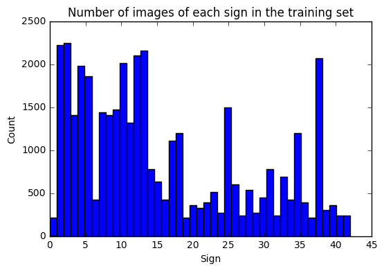

```python
# Plot a histogram of the count of the number of examples of each sign
# in the trainig set

plt.hist(y_train, bins=n_classes)
plt.title('Number of images of each sign in the training set')
plt.xlabel('Sign')
plt.ylabel('Count')
plt.plot()
```

```python
### Define your architecture here.
### Feel free to use as many code cells as needed.
```

### Question 3

*What does your final architecture look like? (Type of model, layers, sizes, connectivity, etc.) For reference on how to build a deep neural network using TensorFlow, see Deep Neural Network in TensorFlow from the classroom.*

```python
import tensorflow as tf
from tensorflow.contrib.layers import flatten

def JojoCovNet(x):
    # Arguments used for tf.truncated_normal, randomly defines variables for the weights and biases for each layer
    mu = 0
    sigma = 0.1

    #_____________________________________________________________________________
    # Layer 1: Convolutional. Input = 32x32x3. Output = 28x28x32.
    #_____________________________________________________________________________
    # Number of Filters K
    K = 32

    # Their spatial extent F (FxF)
    F = 3

    # The Stride S
    S = 1
    strides = [1, S, S, 1]

    # The Padding P
    padding='VALID'

    # Number of Channels on the input
    Ch = image_shape[2]

    conv1_W = tf.Variable(tf.truncated_normal(shape=(F, F, Ch, K), mean = mu, stddev = sigma))
    conv1_b = tf.Variable(tf.zeros(K))
    conv1   = tf.nn.conv2d(x, conv1_W, strides, padding) + conv1_b

    #_____________________________________________________________________________
    # Layer 2 MaxPooling.
    #_____________________________________________________________________________
    # Pooling window size P
    P = 2
    # Stride of the Pooling window S
    S = 2
    layer2 = tf.nn.max_pool(conv1, ksize=[1, P, P, 1], strides=[1, S, S, 1], padding='VALID')

    #_____________________________________________________________________________
    # Layer 3 Dropout.
    #_____________________________________________________________________________
    # dropout rate: dropoutRate
    # I will start with 50% and try different values to tune and observe results
    dropoutRate = 0.5

    layer3 = tf.nn.dropout(layer2, dropoutRate)

    #_____________________________________________________________________________
    # Layer 4 Activation: ReLu
    #_____________________________________________________________________________
    layer4 = tf.nn.relu(layer3)

    #_____________________________________________________________________________
    # Layer 5 Flatten.
    #_____________________________________________________________________________
    fc0   = flatten(layer4)

    #_____________________________________________________________________________
    # Layer 6: Fully Connected. Output = 128.
    #_____________________________________________________________________________
    fc1_W = tf.Variable(tf.truncated_normal(shape=(7200, 128), mean = mu, stddev = sigma))
    fc1_b = tf.Variable(tf.zeros(128))
    fc1   = tf.matmul(fc0, fc1_W) + fc1_b

    #_____________________________________________________________________________
    # Layer 7 Activation: ReLu
    #_____________________________________________________________________________
    layer7 = tf.nn.relu(fc1)

    #_____________________________________________________________________________
    # Layer 8 Flatten.
    #_____________________________________________________________________________
    fc2   = flatten(layer7)

    #_____________________________________________________________________________
    # Layer 9: Fully Connected. Output = # classes.
    #_____________________________________________________________________________
    fc3_W = tf.Variable(tf.truncated_normal(shape=(128, n_classes), mean = mu, stddev = sigma))
    fc3_b = tf.Variable(tf.zeros(n_classes))
    logits = tf.matmul(fc2, fc3_W) + fc3_b

    # Note: Softmax will be performed outside the model


    return logits
```

```python
### Train your model here.
#_____________________________________________________________________________
#    TRAINING PARAMETERS
#_____________________________________________________________________________
aLearning_rate = 0.001
epochs = 30 # Very large number initially that will get optimized when we reach the desired/target accuracy (see below runing the training loop)
batch_size = 128


#_____________________________________________________________________________
#      CONTRUCT THE MODEL
#_____________________________________________________________________________
# x is a placeholder for a batch of input images.
# y is a placeholder for a batch of output labels.
x = tf.placeholder(tf.float32, (None, image_shape[0], image_shape[1], image_shape[2]))
y = tf.placeholder(tf.int32, (None))
one_hot_y = tf.one_hot(y, n_classes)


# Contruct the model line
logits = JojoCovNet(x)

# Define our Cross Entropy, Cost Function, optimizer type and Optimazer operation: minimize cost function
cross_entropy = tf.nn.softmax_cross_entropy_with_logits(logits, one_hot_y)
cost_function = tf.reduce_mean(cross_entropy)
optimizer = tf.train.AdamOptimizer(learning_rate = aLearning_rate)
training_operation = optimizer.minimize(cost_function)

### Feel free to use as many code cells as needed.
```

```python
#_____________________________________________________________________________
#      DEFINE HOW WE WILL EVALUATE THE MODEL
#_____________________________________________________________________________
correct_prediction = tf.equal(tf.argmax(logits, 1), tf.argmax(one_hot_y, 1))
accuracy_operation = tf.reduce_mean(tf.cast(correct_prediction, tf.float32))
saver = tf.train.Saver()

def evaluate(X_data, y_data):
    num_examples = len(X_data)
    total_accuracy = 0
    sess = tf.get_default_session()
    for offset in range(0, num_examples, batch_size):
        batch_x, batch_y = X_data[offset:offset+batch_size], y_data[offset:offset+batch_size]
        accuracy = sess.run(accuracy_operation, feed_dict={x: batch_x, y: batch_y})
        total_accuracy += (accuracy * len(batch_x))
    return total_accuracy / num_examples
```

```python
#_____________________________________________________________________________
#      TRAIN THE MODEL
#_____________________________________________________________________________
import numpy

# Function to initialise the variables
initialize = tf.global_variables_initializer()

validation_accuracy = []
test_accuracy = []

with tf.Session() as sess:
    sess.run(initialize)

    print("Training...")
    print()
    for i in range(epochs):
        X_train_final, y_train_final = shuffle(X_train_final, y_train_final)
        for offset in range(0, n_train, batch_size):
            end = offset + batch_size
            batch_x, batch_y = X_train_final[offset:end], y_train_final[offset:end]
            sess.run(training_operation, feed_dict={x: batch_x, y: batch_y})

        validation_accuracy.append(evaluate(X_validation, y_validation))
        print("EPOCH {} ...".format(i+1))
        print("Validation Accuracy = {:.3f}".format(validation_accuracy[i]))
        print()

        # When we reach an accurancy of 96% we can get out and record at the num of Epochs required to achieve it.
        # This num of Epochs would be the optimal one...without the need to go though all of them
        if validation_accuracy[i] > 0.90:
            test_accuracy.append(evaluate(X_test, y_test))
            print("Test Accuracy = {:.3f}".format(test_accuracy[i]))
        else:
            test_accuracy.append(0.0) # We don't perform the Evaluation over the Test Set when the Validation accuracy is lower than 95%

        if test_accuracy[i] > 0.86:
            print("Optimization Achieved on Epoch:", str(i+1))
            break

    saver.save(sess, './JojoCovNet')
    print("Model saved")

    numpy.savetxt("./Logs/epochsAccuracies4.csv", (validation_accuracy,test_accuracy), delimiter=",")
    print("Epochs Accuracies saved")
```

```
Training...

EPOCH 1 ...
Validation Accuracy = 0.638

EPOCH 2 ...
Validation Accuracy = 0.637

EPOCH 3 ...
Validation Accuracy = 0.606

EPOCH 4 ...
Validation Accuracy = 0.728

EPOCH 5 ...
Validation Accuracy = 0.883

EPOCH 6 ...
Validation Accuracy = 0.713

EPOCH 7 ...
Validation Accuracy = 0.909

Test Accuracy = 0.803
EPOCH 8 ...
Validation Accuracy = 0.929

Test Accuracy = 0.841
EPOCH 9 ...
Validation Accuracy = 0.847

EPOCH 10 ...
Validation Accuracy = 0.852

EPOCH 11 ...
Validation Accuracy = 0.960

Test Accuracy = 0.864
Optimization Achieved on Epoch: 11
Model saved
Epochs Accuracies saved
```

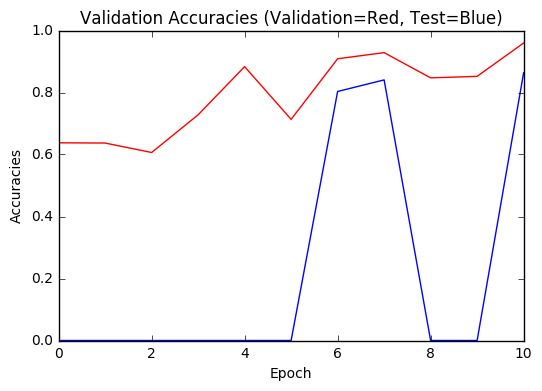

```
Max Test Accuracy: 0.863578780596
Epoch: 11
```

```python
#_____________________________________________________________________________
#      HOW TO CHOSE THE RIGHT
#     EPOCH NUM FOR THIS CASE
#_____________________________________________________________________________
import matplotlib.pyplot as plt
from numpy import genfromtxt

accuracies = genfromtxt('./Logs/epochsAccuracies4.csv', delimiter=',')
plt.plot(accuracies[0],'r')
plt.plot(accuracies[1],'b')
plt.title('Validation Accuracies (Validation=Red, Test=Blue)')
plt.ylabel('Accuracies')
plt.xlabel('Epoch')
plt.show()

print ("Max Test Accuracy:",np.max(accuracies[1]))
print ("Epoch:",np.argmax(accuracies[1])+1)
```

# Epoch Accuracies Data (Over 150 Epochs)

Looking for treands/convergence and transients

[figure not shown]

Source: Munir Jojo-Verge

```python
#_____________________________________________________________________________
#      TEST THE MODEL
#     ON THE TEST DATA
#_____________________________________________________________________________

# There is no need to run this Cell since I run the evaluation over the Test Data above.
#Just decided to keep it for reference.
with tf.Session() as sess:
    saver.restore(sess, tf.train.latest_checkpoint('.'))

    test_accuracy_final = evaluate(X_test, y_test)
    print("Test Accuracy = {:.3f}".format(test_accuracy))
```

Test Accuracies Recorded: Epochs Max Validation Accuracy Test Accuracy 150 0.985845447468 0.746 14 0.963274674843 0.805 29 0.978194338057 0.869

### Question 4

*How did you train your model? (Type of optimizer, batch size, epochs, hyperparameters, etc.)*

**Answer:** Optimizer: I’m using the “AdamOptimizer” since it was suggested to be a better choice than the Gradient Descent. But why?? : http://stats.stackexchange.com/questions/184448/difference-between-gradientdescentoptimizer-and-adamoptimizer-tensorflow The AdamOptimizer uses Kingma and Ba's Adam algorithm to control the learning rate. Adam offers several advantages over the simple tf.train.GradientDescentOptimizer. Foremost is that it uses moving averages of the parameters (momentum); Bengio discusses the reasons for why this is beneficial in Section 3.1.1 of this paper. Simply put, this enables Adam to use a larger effective step size, and the algorithm will converge to this step size without fine tuning.

The main down side of the algorithm is that Adam requires more computation to be performed for each parameter in each training step (to maintain the moving averages and variance, and calculate the scaled gradient); and more state to be retained for each parameter (approximately tripling the size of the model to store the average and variance for each parameter). A simple tf.train.GradientDescentOptimizer could equally be used in your MLP, but would require more hyperparameter tuning before it would converge as quickly.

[output not shown]

### Question 5

*What approach did you take in coming up with a solution to this problem? It may have been a process of trial and error, in which case, outline the steps you took to get to the final solution and why you chose those steps. Perhaps your solution involved an already well known implementation or architecture. In this case, discuss why you think this is suitable for the current problem.*

**Answer:** My approach was to start with what we learnt first (LeNet -5) as the foundation for my architecture. This process lead me to wonder about the reasons behind the values of the hyperparameters on each layer and also wonder about the number of layers. I ended up going deep into the rabbit hole reading and watching lectures on the different architectures (AlexNet, ZFNet, VGGNet, GoogLeNet, …) that have been used in the field of image processing and image classification. All this research made my initial architecture evolve and change significantly as you can see. I ended up with this architecture after starting to play with Keras and observing that this proposed architectire produced nice results for Sign classification I did go a trial and error approach to determine the optimal DropOut rate. I started with 50%, recorded my validation and testing accuracies for different epochs. I tried 60% and 70% and I noticed that it took more epochs to achieve a validation accuracy >96%. I did try 40% and I also noticed the same thing. Due to the time consuming process, I decided to stay with 50% and stop the tuning process.

## Step 3: Test a Model on New Images

Take several pictures of traffic signs that you find on the web or around you (at least five), and run them through your classifier on your computer to produce example results. The classifier might not recognize some local signs but it could prove interesting nonetheless.

You may find `signnames.csv` useful as it contains mappings from the class id (integer) to the actual sign name.

### Implementation

Use the code cell (or multiple code cells, if necessary) to implement the first step of your project. Once you have completed your implementation and are satisfied with the results, be sure to thoroughly answer the questions that follow.

```python
### Load the images and plot them here.
import matplotlib.image as mpimg
def load_image(image_path):

    #reading in an image
    image = mpimg.imread(image_path)
    #printing out some stats and plotting
    #print('This image is:', type(image), 'with dimensions:', image.shape)
    #plt.imshow(image)  #call as plt.imshow(gray, cmap='gray') to show a grayscaled image
    return image

### Feel free to use as many code cells as needed.
```

```python
def predict(img):
    classification = sess.run(tf.argmax(logits, 1), feed_dict={x: [img]})
    #print(classification)
    #print('NN predicted', classification[0])
    return classification[0]
```

```
Image 1 is classified as: 9-No passing
Image 2 is classified as: 18-General caution
Image 3 is classified as: 5-Speed limit (80km/h)
Image 4 is classified as: 2-Speed limit (50km/h)
Image 5 is classified as: 4-Speed limit (70km/h)
Image 6 is classified as: 35-Ahead only
```

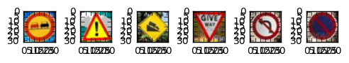

```python
with tf.Session() as sess:
    saver.restore(sess, tf.train.latest_checkpoint('.'))
    # Load an color image
    for i in range(6):
        img = load_image('./images/32x32/Test' + str(i+1) + '.jpg')
        plt.subplot(6,6,i+1)
        plt.imshow(img)
        signName_idx = predict(img)
        print ('Image ' + str(i+1) + ' is classified as: ' + str(signName_idx) + "-" + SignDescription(signName_idx))
```

### Question 6

*Choose five candidate images of traffic signs and provide them in the report. Are there any particular qualities of the image(s) that might make classification difficult? It could be helpful to plot the images in the notebook.*

```python
### Run the predictions here.
## SEE ABOVE.
### Feel free to use as many code cells as needed.
```

### Question 7

*Is your model able to perform equally well on captured pictures when compared to testing on the dataset? The simplest way to do this check the accuracy of the predictions. For example, if the model predicted 1 out of 5 signs correctly, it's 20% accurate.*

**NOTE:** You could check the accuracy manually by using `signnames.csv` (same directory). This file has a mapping from the class id (0-42) to the corresponding sign name. So, you could take the class id the model outputs, lookup the name in `signnames.csv` and see if it matches the sign from the image.

**Answer:** Unfortunately it does not perform equally well on captured images. It has a performance of (2 out of 6) 33% accuracy on captured images as opposed to 86.35% on the test set.

I pre-processed the images and cropped them to be 32x32 and their quality was reduced significantly as you can see on the plots.

```
Image 1 is classified as: 9-No passing
Top five:  TopKV2(values=array([[ 1.,  0.,  0.,  0.,  0.]], dtype=float32), indices=array([[9, 0, 1, 2, 3]]))
Image 2 is classified as: 18-General caution
Top five:  TopKV2(values=array([[ 1.,  0.,  0.,  0.,  0.]], dtype=float32), indices=array([[18,  0,  1,  2,  3]]))
Image 3 is classified as: 17-No entry
Top five:  TopKV2(values=array([[ 1.,  0.,  0.,  0.,  0.]], dtype=float32), indices=array([[17,  0,  1,  2,  3]]))
Image 4 is classified as: 2-Speed limit (50km/h)
Top five:  TopKV2(values=array([[ 1.,  0.,  0.,  0.,  0.]], dtype=float32), indices=array([[2, 0, 1, 3, 4]]))
Image 5 is classified as: 4-Speed limit (70km/h)
Top five:  TopKV2(values=array([[ 1.,  0.,  0.,  0.,  0.]], dtype=float32), indices=array([[4, 0, 1, 2, 3]]))
Image 6 is classified as: 35-Ahead only
Top five:  TopKV2(values=array([[ 1.,  0.,  0.,  0.,  0.]], dtype=float32), indices=array([[35,  0,  1,  2,  3]]))
```

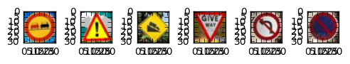

```python
### Visualize the softmax probabilities here.
with tf.Session() as sess:
    saver.restore(sess, tf.train.latest_checkpoint('.'))
    # Load an color image
    for i in range(6):
        img = load_image('./images/32x32/Test' + str(i+1) + '.jpg')
        plt.subplot(6,6,i+1)
        plt.imshow(img)
        signName_idx = predict(img)
        print ('Image ' + str(i+1) + ' is classified as: ' + str(signName_idx) + "-" + SignDescription(signName_idx))
        top_five = sess.run(tf.nn.top_k(tf.nn.softmax(logits), k=5), feed_dict={x: [img]})
        print("Top five: ", top_five)
### Feel free to use as many code cells as needed.
```

### Question 8

*Use the model's softmax probabilities to visualize the **certainty** of its predictions, [`tf.nn.top_k`](https://www.tensorflow.org/versions/r0.12/api_docs/python/nn.html#top_k) could prove helpful here. Which predictions is the model certain of? Uncertain? If the model was incorrect in its initial prediction, does the correct prediction appear in the top k? (k should be 5 at most)*

`tf.nn.top_k` will return the values and indices (class ids) of the top k predictions. So if k=3, for each sign, it'll return the 3 largest probabilities (out of a possible 43) and the correspoding class ids.

Take this numpy array as an example:

```
# (5, 6) array
a = np.array([[ 0.24879643,  0.07032244,  0.12641572,  0.34763842,  0.07893497,
         0.12789202],
       [ 0.28086119,  0.27569815,  0.08594638,  0.0178669 ,  0.18063401,
         0.15899337],
       [ 0.26076848,  0.23664738,  0.08020603,  0.07001922,  0.1134371 ,
         0.23892179],
       [ 0.11943333,  0.29198961,  0.02605103,  0.26234032,  0.1351348 ,
         0.16505091],
       [ 0.09561176,  0.34396535,  0.0643941 ,  0.16240774,  0.24206137,
         0.09155967]])
```

Running it through `sess.run(tf.nn.top_k(tf.constant(a), k=3))` produces:

```
TopKV2(values=array([[ 0.34763842,  0.24879643,  0.12789202],
       [ 0.28086119,  0.27569815,  0.18063401],
       [ 0.26076848,  0.23892179,  0.23664738],
       [ 0.29198961,  0.26234032,  0.16505091],
       [ 0.34396535,  0.24206137,  0.16240774]]), indices=array([[3, 0, 5],
       [0, 1, 4],
       [0, 5, 1],
       [1, 3, 5],
       [1, 4, 3]], dtype=int32))
```

Looking just at the first row we get `[ 0.34763842, 0.24879643, 0.12789202]`, you can confirm these are the 3 largest probabilities in `a`. You'll also notice `[3, 0, 5]` are the corresponding indices.

```python
# Close my tf session.
sess.close()
```